# 1 Quantos são os papeis na urna ?

## 1.1 Objetivo

Introduzir os visitantes da mostra a ideia de estimação de quantidades de totais.

## 1.2 Construção

Para esse experimento são necessários:

- Uma urna transparente, de preferência de forma cubica.
- Grande quantidade de papeis enrolados ou qualquer outro elemento de pequeno tamanho.

## 1.3 Execução

Primeiramente pergunta-se ao visitante qual é o valor que ele acredita que corresponda a quantidade de papeis que estão contidos na urna logo após pode-se sugerir métodos para estimar esse valor.

Após o palpite ser dado a ideia por de trás de cada um dos possíveis métodos deve ser explicada.

## 1.4 Teoria

### 1.4.1 Estimando o total usando amostragem aleatória simples

Considerando o volume ocupado pelos $N$ rolinhos de papel na urna como sendo $V$ podemos particiona-lo em $q$ porções de igual volume $v$.

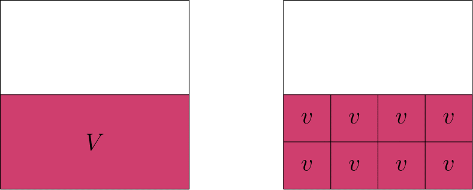

Figure 1.1: Fracionando o volume V em q porçoes de volume v

Note que $V = vq$.

Agora considerando que cada porção $v$ contem $n$ papeis, temos:

$$N = nq$$

Logo teoricamente para encontrarmos o total $N$ precisamos somente retirar uma amostra ou porção de volume $v$ e conhecer os valores $q$ e $n$.

Possíveis causas de erro para esse método são:

- Os papeis não são uniformes, variam em tamanho.
- Erro ao particionar V, as porções possuem volume diferente logo contem quantidades diferentes de papeis.

Assumindo que exista variação no número de papeis em cada porção uma alternativa para minimizar o erro ao estimar o total seria tomar mais de uma amostra.

Suponha que foram tomadas $k$ amostras, $1\leq k \leq q$, temos:

$$\bar{n} = \frac{1}{k}\sum_{i = 1}^k \mathit{n_i}$$
Onde $n_i$ é a quantidade de papeis contidos na i-ésima porção, por fim temos $\bar{N} = \bar{n}q$.

Quanto maior for o número de amostras tomadas maior é a chance do valor estimado $\bar{N}$ estar perto do valor real $N$.

### 1.4.2 Estimação do total via “sabedoria das multidões”

A ideia de sabedoria das multidões, *wisdom of crowds* em inglês, diz que um coletivo de opiniões e melhor ou mais acurado que a maioria de suas componentes, logo aplicando essa ideia ao experimento temos que se tomarmos a média ou mediana dos palpites esse resultado estará mais próximo, comparado a maioria das opiniões, à real quantidade de papeis na urna.

O caso notório que deu início a ideia de sabedoria das multidões ocorreu no ano de 1906 em uma feira rural em *Plymouth* na Inglaterra onde 800 pessoas participaram de um concurso para estimar o peso total de um boi abatido e preparado. O estatístico Francis Galton observou que a mediana dos palpites observados, 1.207 libras, era preciso dentro de 1% do peso real de 1.198 libras. Isso contribuiu para a percepção da ciência cognitiva de que os julgamentos individuais de uma multidão podem ser modelados como uma distribuição de probabilidade de respostas com a mediana centralizada próxima ao valor real da quantidade a ser estimada.

Vale ressaltar que para a aplicação da ideia de sabedoria das multidões os palpites tem que ser independentes e não viesados.

## 1.5 Referências e leituras complementares

**Pedro Luis do Nascimento Silva, Zélia Magalhães Bianchini e Antonio José Ribeiro Dias**. “Estatísticas, estimadores e estimativas”, disponível em: https://amostragemcomr.github.io/livro/visger.html#estat%C3%ADsticas-estimadores-e-estimativas

**David Webb**. “The Wisdom of Crowds (Vox Populi) by Francis Galton”, disponível em: https://www.all-about-psychology.com/the-wisdom-of-crowds.html